# Introduction to linear regression

Data Science for Biologists, Spring 2020

Poonam Shah

## Instructions

This assignment will use an external dataset from a field experiment studying the diversity of [Chinese Rowan](https://en.wikipedia.org/wiki/Rowan) trees. Researchers randomly sampled and recorded characteristics of leaves from three different species in the *Sorbus* genus. They recorded the following measurements for each tree (don’t worry about units)

For this assignment, you will examine how various predictors may explain variation in *respiratory rate.*

```r
# rowan trees
rowan <- read_csv("https://raw.githubusercontent.com/sjspielman/datascience_for_biologists/master/data/rowan_trees.csv")
dplyr::glimpse(rowan)
```

```
## Observations: 300
## Variables: 5
## $ species          <chr> "microphylla", "microphylla", "microphylla", "microp…
## $ altitude         <dbl> 457, 644, 497, 412, 460, 467, 394, 474, 475, 397, 51…
## $ respiratory_rate <dbl> 0.266, 0.272, 0.231, 0.108, 0.216, 0.291, 0.244, 0.0…
## $ leaf_len         <dbl> 8.7, 9.5, 7.9, 9.5, 10.1, 9.1, 7.2, 9.7, 8.6, 9.3, 8…
## $ nesting_birds    <chr> "n", "n", "y", "y", "n", "y", "n", "n", "n", "y", "n…
```

### Question 1

> Background for this completing question is under the header “Simple linear regression: Single numeric predictor” in the linear regression tutorial

Construct a linear model that examines how *altitude* might explain variation in *respiratory rate*. Take the following steps to do so (code as you go through the steps!)

Make a quick scatter plot to make sure the “linear relationship” assumption is met for this data. Be sure to have your predictor and response on the correct axis!:

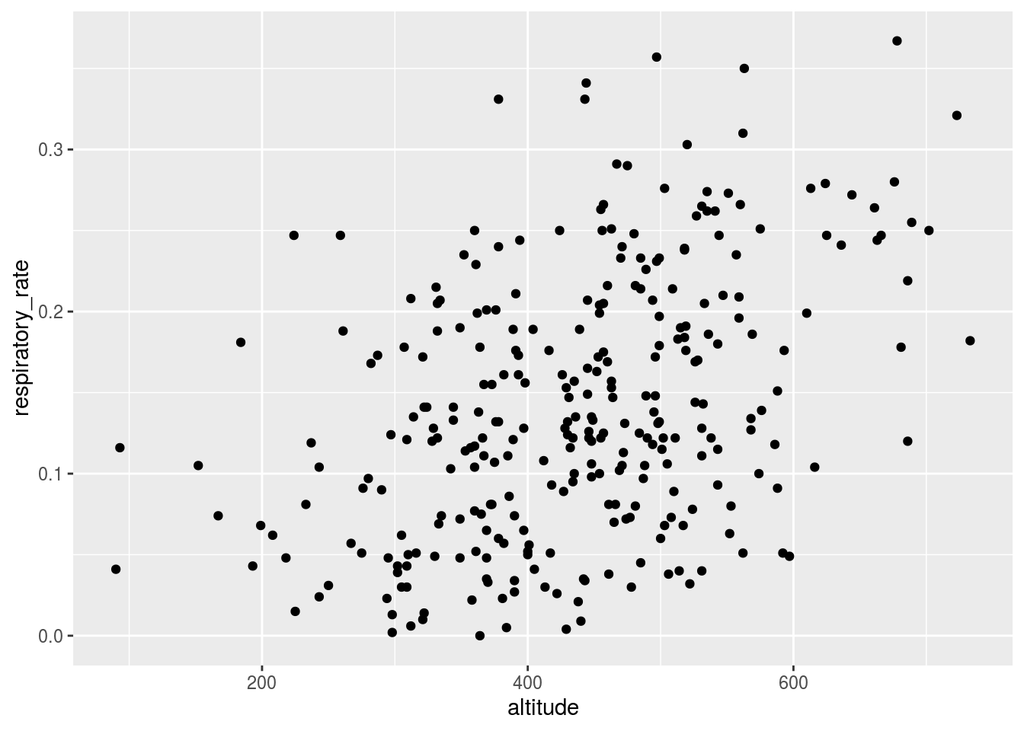

```r
### figure to check linearity goes here.
### no need for fancy, can keep labels as is, etc.

ggplot(rowan, aes(x= altitude, y=respiratory_rate)) + geom_point()
```

Now that you have confirmed the relationship is linear (hint: it is linear), build your linear model. *BEFORE you examine its output*, evaluate whether the model residuals were normally distributed:

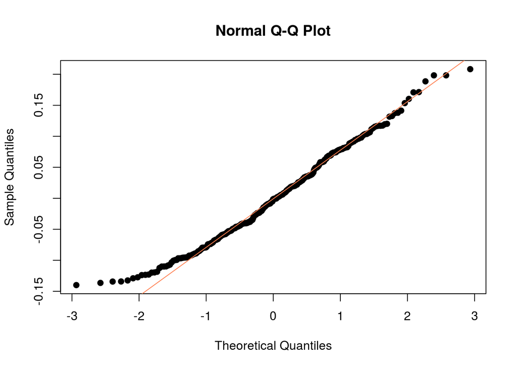

```r
### build model and check normal residuals
### do not look at the model summary yet!
#Y-X
fit <- lm(respiratory_rate~altitude, data = rowan)
#get the residuls
broom::augment(fit, rowan) -> augmented_fit

qqnorm(augmented_fit$.resid, pch =19)
qqline(augmented_fit$.resid, col ="coral")
```

Now that you have confirmed the residuals are roughly normally distributed (hint: they are), examine the output from your linear model. In the space below the code chunk, discuss in *bullet form* (1-2 sentences each): a) Provide an interpretation of the intercept, b) Provide an interpretation of the altitude coefficient, c) Provide an interpretation of the $R^2$ value (those dollar signs signify “math mode” - see the HTML output!), and finally d) Conclude whether altitude is a strong or weak predictor of respiratory rate, consider “biological significance” (effect size!) as well as statistical significance.

```r
## examine model output here
summary(fit)
```

```
##
## Call:
## lm(formula = respiratory_rate ~ altitude, data = rowan)
##
## Residuals:
##      Min       1Q   Median       3Q      Max
## -0.13997 -0.05365 -0.00145  0.05206  0.20827
##
## Coefficients:
##              Estimate Std. Error t value Pr(>|t|)
## (Intercept) 8.386e-03  1.702e-02   0.493    0.622
## altitude    3.025e-04  3.778e-05   8.007 2.66e-14 ***
## ---
## Signif. codes:  0 '***' 0.001 '**' 0.01 '*' 0.05 '.' 0.1 ' ' 1
##
## Residual standard error: 0.07333 on 298 degrees of freedom
## Multiple R-squared:  0.177,  Adjusted R-squared:  0.1743
## F-statistic: 64.11 on 1 and 298 DF,  p-value: 2.66e-14
```

Y= 3.02e-04X + 8.386e-03

Finally, make a stylish scatterplot of your findings. Your scatterplot should:

- Use your favorite ggplot theme and colors (it’s allowed to like the default!)
- Clearly show the regression line and its 95% confidence interval
- Include a meaningful title, along with a subtitle that is the fitted model itself, as well as other nice labels
- Include a well-placed annotation that gives the model’s $R^2$

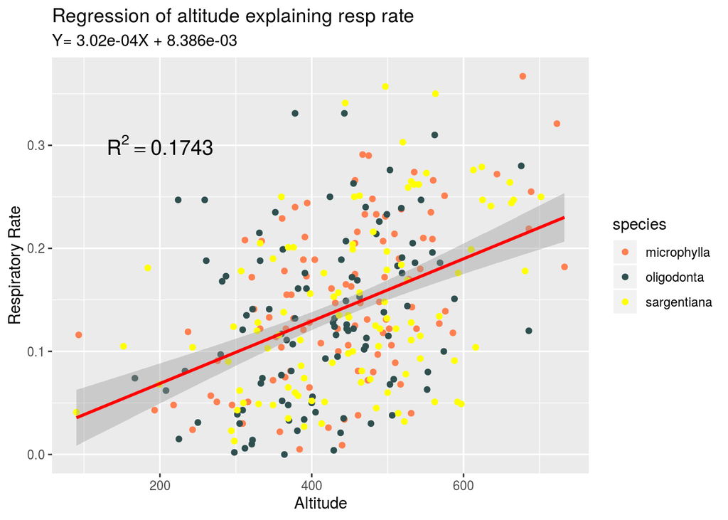

```r
### stylish plot goes here
forumla = "Y= 3.02e-04X + 8.386e-03"
#setting up the graph
ggplot(rowan, aes(x= altitude, y=respiratory_rate, color=species)) +
  geom_point() +
  #added title, subtitle, and clean up the axis
  labs(x= "Altitude",
       y="Respiratory Rate",
       title = "Regression of altitude explaining resp rate",
       subtitle = "Y= 3.02e-04X + 8.386e-03") +
  #added the geom smooth
  geom_smooth(method="lm", color="red") +
  #changed the color of the points
  scale_color_manual(values = c(color_choice_1,color_choice_2, color_choice_3 )) +
  #added the R^2
  annotate("text", x=200, y=0.3, size=5, label = "R^2 ==0.1743", parse= TRUE)
```

### Question 2

> Background for this completing question is under the header “Simple ANOVA: Single categorical predictor” in the linear regression tutorial

Construct a linear model that examines how *species* might explain variation in *respiratory rate*. Take the following steps to do so (code as you go through the steps!)

Make a quick plot (use `geom_point()`, seriously, not even a jitter!!) to make sure the “equal variance” assumption is met for this data:

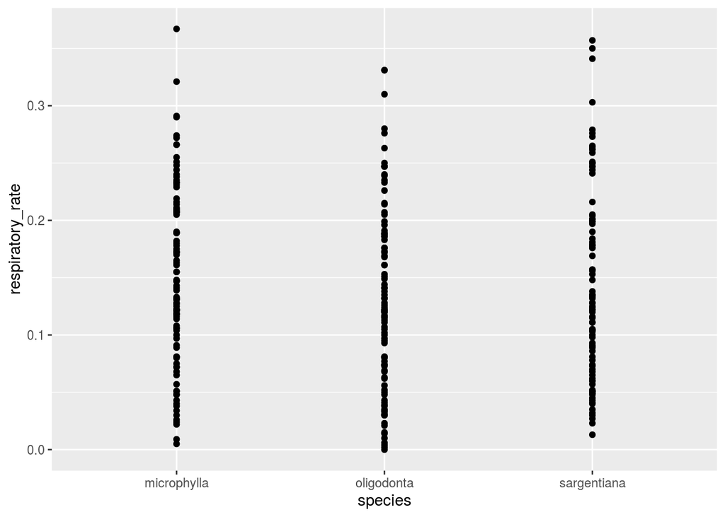

```r
### figure to check assumption goes here.
### no need for fancy, can keep labels as is, etc.
ggplot(rowan, aes(x= species, y=respiratory_rate)) +
  geom_point()
```

Now that you have confirmed the variance is equal across groups (hint: it is), build your linear model. *BEFORE you examine its output*, evaluate whether the model residuals were normally distributed:

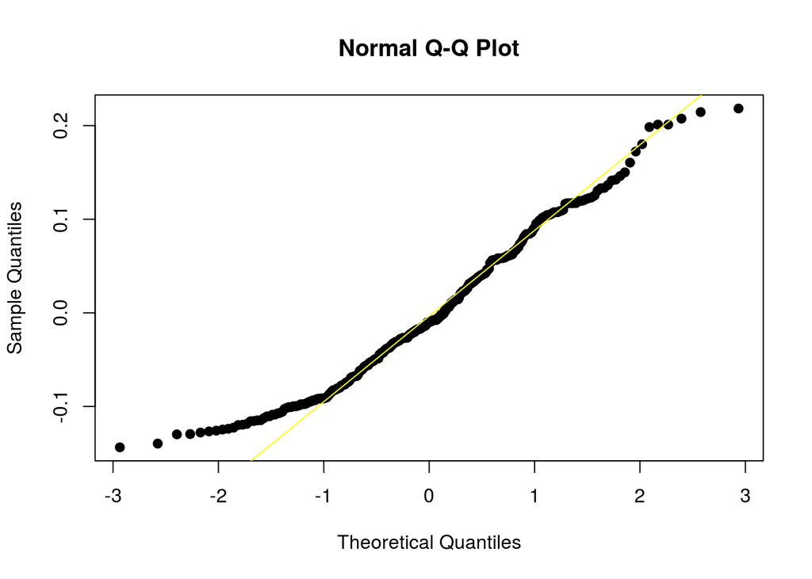

```r
### build model and check normal residuals
### do not look at the model summary yet!
fit <- lm(respiratory_rate~species, data = rowan)
#get the residuals
broom::augment(fit, rowan) -> augmented_fit

qqnorm(augmented_fit$.resid, pch =19)
qqline(augmented_fit$.resid, col ="yellow")
```

Now that you have confirmed the residuals are roughly normally distributed (hint: they are), examine the output from your linear model. In the space below the code chunk, discuss in *bullet form* (1-2 sentences each): a) Provide an interpretation of the intercept, b) Provide an interpretation of the species coefficient, c) Provide an interpretation of the $R^2$ value, and finally d) Conclude whether species is a strong or weak predictor of respiratory rate, consider “biological significance” (effect size!) as well as statistical significance.

```r
## examine model output here

summary(fit)
```

```
##
## Call:
## lm(formula = respiratory_rate ~ species, data = rowan)
##
## Residuals:
##       Min        1Q    Median        3Q       Max
## -0.143680 -0.065088 -0.009765  0.058320  0.218320
##
## Coefficients:
##                     Estimate Std. Error t value Pr(>|t|)
## (Intercept)         0.148680   0.008059  18.450   <2e-16 ***
## speciesoligodonta  -0.018830   0.011397  -1.652   0.0995 .
## speciessargentiana -0.006180   0.011397  -0.542   0.5880
## ---
## Signif. codes:  0 '***' 0.001 '**' 0.01 '*' 0.05 '.' 0.1 ' ' 1
##
## Residual standard error: 0.08059 on 297 degrees of freedom
## Multiple R-squared:  0.009463,   Adjusted R-squared:  0.002792
## F-statistic: 1.419 on 2 and 297 DF,  p-value: 0.2437
```

Y= -0.006180X + 0.148680 #Species sargentiana

y= -0.018830X + 0.148680 #Species Oligodonta

Finally, make a stylish figure of your findings, choosing your own geom!

- Use your favorite ggplot theme and colors (it’s allowed to like the default!)
- If your geom does not already show the center of each group (i.e. like a boxplot), be sure to add the means in with `stat_summary()`
- Include a meaningful title, along with a subtitle that is the fitted model itself, as well as other nice labels
- Include a well-placed annotation that gives the model’s $R^2$

```
## No summary function supplied, defaulting to `mean_se()
```

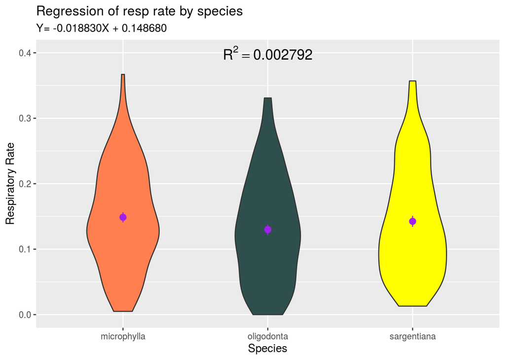

```r
### stylish plot goes here
ggplot(rowan, aes(x=species, y=respiratory_rate, fill=species)) +
  geom_violin(width=0.5) +
  stat_summary(color="purple")+
    labs(x= "Species",
       y="Respiratory Rate",
       title = "Regression of resp rate by species",
       subtitle = "Y= -0.018830X + 0.148680")+
  scale_fill_manual(values = c(color_choice_1,color_choice_2, color_choice_3 ))+
  #added the R^2
  annotate("text", x=2, y=0.4, size=5, label = "R^2 ==0.002792", parse= TRUE)+
  #removed the legend
  theme(legend.position = "none")
```

### Question 3

> Background for this completing question is under the header “LM with numeric and categorical predictors” in the linear regression tutorial

Construct a linear model that examines how BOTH *species* and *leaf_len* as independent effects might explain variation in *respiratory rate*. Again, take the following steps one by one:

Make TWO quick plots to make sure assumptions are met for each of our predictors:

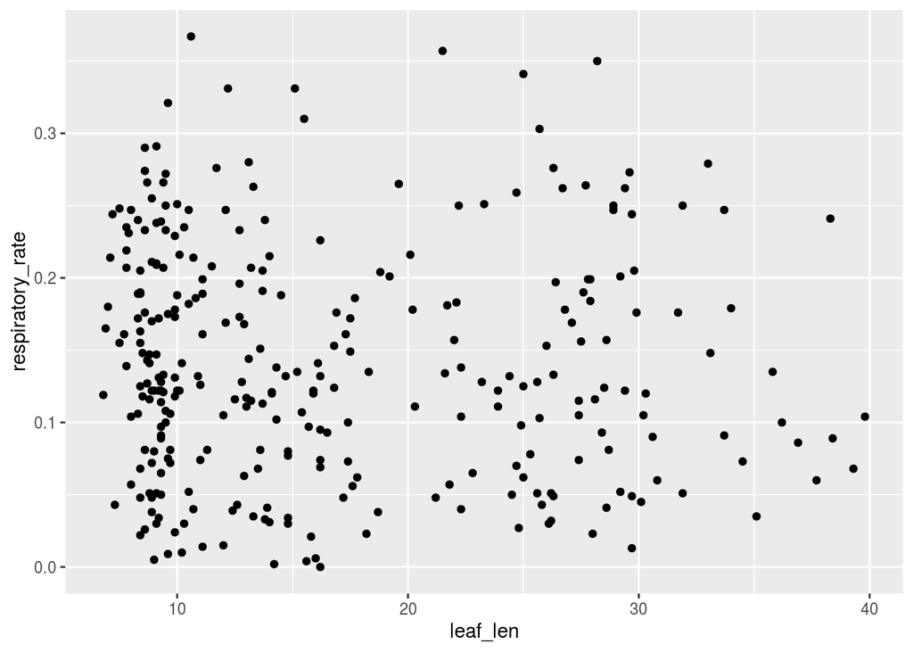

```r
### figures to check assumption goes here.
### no need for fancy, can keep labels as is, etc.

ggplot(rowan, aes(x= leaf_len, y=respiratory_rate)) +
  geom_point()
```

Build your linear model, and evaluate whether the model residuals were normally distributed:

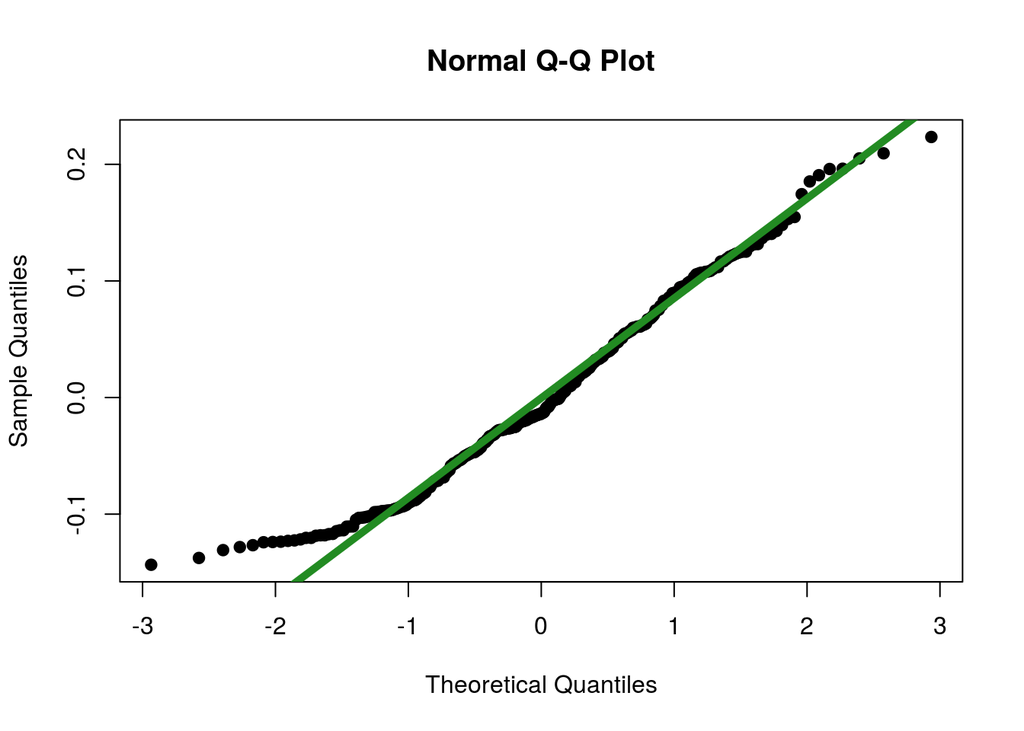

```r
### build model and check normal residuals
### do not look at the model summary yet!
fit <- lm(respiratory_rate~species + leaf_len, data=rowan)

broom::augment(fit, rowan) -> augmented_fit

qqnorm(augmented_fit$.resid, pch =19)
qqline(augmented_fit$.resid, col ="forestgreen", lwd=5)
```

Now that you have confirmed the residuals are roughly normally distributed (hint: they are), examine the output from your linear model. In the space below the code chunk, discuss in *bullet form* (1-2 sentences each): a) Provide an interpretation of the intercept, b) Provide an interpretation of the `species` coefficient, c) Provide an interpretation of the `leaf_len` coefficient d) Provide an interpretation of the $R^2$ value, and finally e) Conclude whether species is a strong or weak predictor of respiratory rate, consider “biological significance” (effect size!) as well as statistical significance.

```r
## examine model output here

summary(fit)
```

```
##
## Call:
## lm(formula = respiratory_rate ~ species + leaf_len, data = rowan)
##
## Residuals:
##      Min       1Q   Median       3Q      Max
## -0.14344 -0.05814 -0.01373  0.05732  0.22345
##
## Coefficients:
##                     Estimate Std. Error t value Pr(>|t|)
## (Intercept)         0.175923   0.015300  11.498   <2e-16 ***
## speciesoligodonta  -0.003898   0.013396  -0.291   0.7713
## speciessargentiana  0.050740   0.029495   1.720   0.0864 .
## leaf_len           -0.003054   0.001461  -2.090   0.0375 *
## ---
## Signif. codes:  0 '***' 0.001 '**' 0.01 '*' 0.05 '.' 0.1 ' ' 1
##
## Residual standard error: 0.08013 on 296 degrees of freedom
## Multiple R-squared:  0.02387,    Adjusted R-squared:  0.01398
## F-statistic: 2.413 on 3 and 296 DF,  p-value: 0.06687
```

Finally, make a stylish scatterplot of your findings:

- Use your favorite ggplot theme and colors (it’s allowed to like the default!)
- Make sure to show a regression lines for EACH species. **NOTICE in theses lines** how they are consistent with your conclusions about species being a significant predictor. You do not have to write anything, just notice!
- Include a meaningful title, along with a subtitle that is the fitted model itself, as well as other nice labels
- Include a well-placed annotation that gives the model’s $R^2$

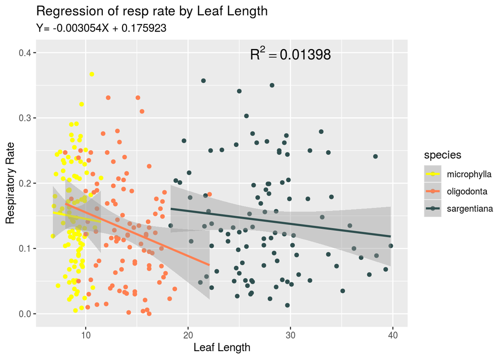

```r
### stylish plot goes here
ggplot(rowan, aes(x=leaf_len, y= respiratory_rate, color= species))+
  geom_point()+
  geom_smooth(method = "lm",aes(color= species)) +
      labs(x= "Leaf Length",
       y="Respiratory Rate",
       title = "Regression of resp rate by Leaf Length",
       subtitle = "Y= -0.003054X + 0.175923")+
  scale_color_manual(values = c(color_choice_3,color_choice_1, color_choice_2 ))+
  #added the R^2
  annotate("text", x=30, y=0.4, size=5, label = "R^2 ==0.01398 ", parse= TRUE)
```